© Guven

# Data Features

## Introduction

Given a dataset of $M$ variables and $N$ dataset points (number of samples), a feature is one of the **independent** variables in a dataset and is also called a **predictor**. Generally, the input to a machine learning program is a column of a tabular dataset where each row (of $N$ rows) is a dataset point in $M$ dimensional space.

In our Jupyter notebooks, we will use the matrix $X_{N \times M}$ as the dataset symbol without the dependent variable (also called the label, category, class, or predicted variable), and we will store the dependent variable in the vector $y_{N \times 1}$.

$X$ is a matrix. Its rows are data points, and its columns are the features. All classifiers in `scikit-learn` can understand this data format based on `numpy` 2-dimensional arrays. Thus, for each input data point, we have $x \in \mathbb{R}^M$ and $N$ data points to be used in our ML pipelines. We also have $y \in \mathbb{Z}^+$ in general as the category. As an example, if we have $K$ categories, then $y \in \{ k : 0 \leq k < K, k \in \mathbb{Z}^+ \}$

**Example:** In the following $X$ matrix, we have 3 features and 5 data points, i.e., $M=3$ and $N=5$. We also have $5$ values for the dependent variable $y$.

$X= \begin{bmatrix} x_{11}&x_{12}&x_{13} \\ x_{21}&x_{22}&x_{23} \\ x_{31}&x_{32}&x_{33} \\ x_{41}&x_{42}&x_{43} \\ x_{51}&x_{52}&x_{53} \end{bmatrix}$, $y=\begin{bmatrix} y_{1} \\ y_{2} \\ y_{3} \\ y_{4} \\ y_{5} \end{bmatrix}$ $\hspace{1cm}$ Such that in practice, $X= \begin{bmatrix} 4.9 & 3. & 1.4 \\ 4.7 & 3.2 & 1.3 \\ 4.6 & 3.1 & 1.5 \\ 5. & 3.6 & 1.4 \\ 5.4 & 3.9 & 1.7 \end{bmatrix}$, $y=\begin{bmatrix} 1 \\ 0 \\ 0 \\ 1 \\ 2 \end{bmatrix}$

where the dependent variable $y$ has levels from the alphabet $\Sigma = \{0, 1, 2\}$, i.e. there are 3 categories in the given dataset.

The predicted variable or label is the **dependent** variable, which is *dependent* on the **independent variables** or features. This amount of dependence can sometimes be high and sometimes very low, depending on the dataset or the nature of the problem (again, the dataset expresses this). If there is no correlation (or fully independent), then the dataset may not be suitable for the problem at hand, and/or we may have to remove that feature from the dataset.

As an example, for numerical variables, the Pearson correlation coefficient of two variables $x$ (lower case x, a feature) and $y$ is defined as:

$r_{xy}=\dfrac {\sum_{i=1}^N{(x_i-\bar{x})(y_i-\bar{y})}} {\sqrt{\sum_{i=1}^N{(x_i-\bar{x})^2}}\sqrt{\sum_{i=1}^N{(y_i-\bar{y})^2}}}$, where $\bar{x}$ and $\bar{y}$ are sample means.

Ideally, we need a good correlation (close to 1 or -1) between the independent and dependent (predicted) variables so our ML model would actually work.

**Question:** Can the correlation coefficient be used to determine important features for the machine learning model?

## Data types

- Numerical - Can be integer $\mathbb{Z}$ or floating point $\mathbb{R}$. Generally, it is safe to convert all numerical variables to floating point variables
- Nominal - The variable values are drawn from a finite set of **levels** or from an alphabet $\Sigma$
  - Ordinal types are nominals with a natural order, such as small, medium, big
- Binary - The variable values can be either `0` or `1` (or `False` or `True`). Some algorithms work fast on this kind of values, especially constrained optimization-related methods
- String - May not be used directly unless the ML program (preprocessing) knows how to deal with it
- Date - May not be used directly unless the ML program (preprocessing) knows how to deal with it. It might be a good idea to convert (or map) dates to some integer numbers - for example, Excel handles dates in this manner
- More complicated features, e.g., a DNA sequence (sequence of {A,C,G,T} letters) - Other, simpler features need to be extracted from the input sequence so that this higher-level feature can be used in an ML program

### Nominal to Numerical Conversion

One possible way of converting nominal variables to numerical is **one-hot encoding**:

1. During preprocessing, count the number of levels in the set of possible levels a nominal variable $v_{nom}$ takes. Such as, $L$ different levels, $k=1,\dots,L$.
2. Create $L$ binary variables for that nominal variable $v_{nom}$ where each row will have a binary zero for $L-1$ binary variables except for the j<sup>th</sup> level which corresponds to the level-j when $v_{nom}$ takes a value of level-j.

Following the above procedure, a nominal variable with a cardinality of $L$ results in $L$ many binary variable creation (and dropping the original nominal variable itself). In other words, each unique level of that nominal variable is mapped to a binary variable. Note that, for the sake of this representation, storage space is wasted.

Also observe that the one-hot encoded variables are like *Cartesian basis* of linear algebra, e.g., a feature one-hot encoded to 3 dimensions of $x$, $y$, $z$.

Conversion of nominal variables to numerical is an important step for many numerical-only classifiers, such as neural networks, support vector machines, and linear regression.

Note that using `sklearn.preprocessing.LabelEncoder` will impose *ordinal* numerical values, which may not be correct and cause bias. Therefore, it should be avoided. Instead, use `OneHotEncoder`.

#### Example One-hot Encoding

The nominal variable $T$ take **levels** from the $\Sigma=\{\text{low},\text{medium},\text{high}\}$. Numerical conversion involves each unique level being mapped to one of the $T_i$ binary vectors.

| Nominal Variable `T` | `T0` | `T1` | `T2` |
| --- | --- | --- | --- |
| low | 1 | 0 | 0 |
| medium | 0 | 1 | 0 |
| low | 1 | 0 | 0 |
| high | 0 | 0 | 1 |
| high | 0 | 0 | 1 |
| low | 1 | 0 | 0 |

### Numerical to Nominal Conversion

Generally, histograms, binning, and bin boundaries are used to group numerical values into levels or one-hot encoded variables.

## Online Dataset Sources

The **UCI KDD** online repository has various datasets that can be used for analysis, machine learning, and several application fields, such as GIS, cybersecurity, NLP, etc. The origin of some datasets goes back more than 20 years and is sourced from competitions, challenges, grants, etc. Researchers and students use these datasets and share their experiences using a common platform.  
Source: UCI Knowledge Discovery in Databases Archive

http://kdd.ics.uci.edu/

The **Kaggle** data repository has various datasets used for Kaggle competitions. The website also has tools to examine the features on-site. This source is one of the largest. Go to the Kaggle dataset source:

https://www.kaggle.com/datasets

https://www.kdnuggets.com/datasets/index.html

The rest of the notebook will demonstrate three different datasets from these repositories.

1. UCI KDD archive $\rightarrow$ 1990 US Census data
2. Kaggle $\rightarrow$ Graduate Admissions data
3. Kaggle $\rightarrow$ The Human Freedom Index data

Download the data files from the UCI KDD website and the Kaggle website (by registering on Kaggle, using a disposable email address if necessary).

**Important Note:** About physical dataset file shared among teams. Comparing machine learning models, and measuring performances for model selection is heavily dependent on the input dataset. Thus, if a comparison between models and a comparison among different experiments or teams results are at hand, then the dataset shared among teams or different set of experiments ___must___ be exactly the *same* dataset. Moreover, to ensure validity, the exact same file should be shared among multiple teams or between different model pipelines.

*WATCH THE MODULE VIDEO* for downloading files from online sources.

## Dataset Curation

In the following cells we use the downloaded and previously **cleaned** data files:

Note that there are two dataset *cleaning* tasks before a machine learning model development can begin:

- Cleaning the data so the framework understands the data right, i.e. formatting, removing confusing symbols, quotes, etc.
- Cleaning (preprocessing) the data to improve the ML task, i.e., imputing values, removing outliers, removing incorrect dataset values, deriving variables, selecting variables, etc.

Both cleaning steps are crucial in preparing the dataset for model development.

**Quote:** "As data scientists, our job is to extract signal from noise." (ref: KDnuggets)

Let's see what our data files contain:

```python
%matplotlib inline
import matplotlib.pyplot as plt
plt.rcParams["figure.dpi"] = 72
import numpy as np
import pandas as pd


# Locate and load the data file
df = pd.read_csv('/EP_datasets/USCensus1990.data.csv')

# Sanity check
print(f'N rows={len(df)}, M columns={len(df.columns)}')
df.head()
```

```
N rows=2458285, M columns=69
```

|  | caseid | dAge | dAncstry1 | dAncstry2 | iAvail | iCitizen | iClass | dDepart | iDisabl1 | iDisabl2 | ... | iTmpabsnt | dTravtime | iVietnam | dWeek89 | iWork89 | iWorklwk | iWWII | iYearsch | iYearwrk | dYrsserv |
| --- | --- | --- | --- | --- | --- | --- | --- | --- | --- | --- | --- | --- | --- | --- | --- | --- | --- | --- | --- | --- | --- |
| 0 | 10000 | 5 | 0 | 1 | 0 | 0 | 5 | 3 | 2 | 2 | ... | 0 | 5 | 0 | 2 | 1 | 1 | 0 | 11 | 1 | 0 |
| 1 | 10001 | 6 | 1 | 1 | 0 | 0 | 7 | 5 | 2 | 2 | ... | 0 | 1 | 0 | 2 | 1 | 1 | 0 | 5 | 1 | 0 |
| 2 | 10002 | 3 | 1 | 2 | 0 | 0 | 7 | 4 | 2 | 2 | ... | 0 | 2 | 0 | 2 | 1 | 1 | 0 | 10 | 1 | 0 |
| 3 | 10003 | 4 | 1 | 2 | 0 | 0 | 1 | 3 | 2 | 2 | ... | 0 | 1 | 0 | 1 | 1 | 1 | 0 | 10 | 1 | 0 |
| 4 | 10004 | 7 | 1 | 1 | 0 | 0 | 0 | 0 | 2 | 2 | ... | 3 | 0 | 0 | 0 | 2 | 2 | 0 | 5 | 6 | 0 |

5 rows × 69 columns

```python
# Locate and load the data file
df = pd.read_csv('/EP_datasets/Admission_Predict_Ver1.1.csv')

# Sanity check
print(f'N rows={len(df)}, M columns={len(df.columns)}')
df.head()
```

```
N rows=500, M columns=9
```

|  | Serial No. | GRE Score | TOEFL Score | University Rating | SOP | LOR | CGPA | Research | Chance of Admit |
| --- | --- | --- | --- | --- | --- | --- | --- | --- | --- |
| 0 | 1 | 337 | 118 | 4 | 4.5 | 4.5 | 9.65 | 1 | 0.92 |
| 1 | 2 | 324 | 107 | 4 | 4.0 | 4.5 | 8.87 | 1 | 0.76 |
| 2 | 3 | 316 | 104 | 3 | 3.0 | 3.5 | 8.00 | 1 | 0.72 |
| 3 | 4 | 322 | 110 | 3 | 3.5 | 2.5 | 8.67 | 1 | 0.80 |
| 4 | 5 | 314 | 103 | 2 | 2.0 | 3.0 | 8.21 | 0 | 0.65 |

```python
# Locate and load the data file
df = pd.read_csv('/EP_datasets/hfi_cc_2018.csv')

# Sanity check
print(f'N rows={len(df)}, M columns={len(df.columns)}')
df.head()
```

```
N rows=1458, M columns=123
```

|  | year | ISO_code | countries | region | pf_rol_procedural | pf_rol_civil | pf_rol_criminal | pf_rol | pf_ss_homicide | pf_ss_disappearances_disap | ... | ef_regulation_business_bribes | ef_regulation_business_licensing | ef_regulation_business_compliance | ef_regulation_business | ef_regulation | ef_score | ef_rank | hf_score | hf_rank | hf_quartile |
| --- | --- | --- | --- | --- | --- | --- | --- | --- | --- | --- | --- | --- | --- | --- | --- | --- | --- | --- | --- | --- | --- |
| 0 | 2016 | ALB | Albania | Eastern Europe | 6.661503 | 4.547244 | 4.666508 | 5.291752 | 8.920429 | 10.0 | ... | 4.050196 | 7.324582 | 7.074366 | 6.705863 | 6.906901 | 7.54 | 34.0 | 7.568140 | 48.0 | 2.0 |
| 1 | 2016 | DZA | Algeria | Middle East & North Africa | NaN | NaN | NaN | 3.819566 | 9.456254 | 10.0 | ... | 3.765515 | 8.523503 | 7.029528 | 5.676956 | 5.268992 | 4.99 | 159.0 | 5.135886 | 155.0 | 4.0 |
| 2 | 2016 | AGO | Angola | Sub-Saharan Africa | NaN | NaN | NaN | 3.451814 | 8.060260 | 5.0 | ... | 1.945540 | 8.096776 | 6.782923 | 4.930271 | 5.518500 | 5.17 | 155.0 | 5.640662 | 142.0 | 4.0 |
| 3 | 2016 | ARG | Argentina | Latin America & the Caribbean | 7.098483 | 5.791960 | 4.343930 | 5.744791 | 7.622974 | 10.0 | ... | 3.260044 | 5.253411 | 6.508295 | 5.535831 | 5.369019 | 4.84 | 160.0 | 6.469848 | 107.0 | 3.0 |
| 4 | 2016 | ARM | Armenia | Caucasus & Central Asia | NaN | NaN | NaN | 5.003205 | 8.808750 | 10.0 | ... | 4.575152 | 9.319612 | 6.491481 | 6.797530 | 7.378069 | 7.57 | 29.0 | 7.241402 | 57.0 | 2.0 |

5 rows × 123 columns

### The Human Freedom Index Dataset

Opening the `hfi_cc_2018` CSV data file in Weka is tricky as it needs two modifications as in below:

- Using a text editor, change the value `"d'Ivoire"` to `"dIvoire"` by removing the single quote. The single quote is used by Weka to mark nominal variables.
- Using a text editor add single quotes to the feature name **region** to mark it as nominal. Weka wants to see single quotes in the variable name (in the header) to be able to load the type of the variables correctly.

This particular example shows that data mining and machine learning frameworks such as Weka have their own standards that the model developer has to pay attention to.

### Weka Framework

*WATCH THE RELATED VIDEO* for opening, using Weka, preprocessing and running Random Forest classifier.

### Graduate Admissions Dataset

Let's open the data file `Admission_Predict.csv` in Weka. Click on `Explorer` and open the CSV file with `Open File` button. We need a dependent variable to predict or do something with it. Let's pick `A9 - Chance of Admit` (`A_XX` is the attribute that starts from index 1). We need to convert this variable to a categorical variable.

Steps to preprocess:

1. In Filter, `AddExpression -E "ifelse (A9 > 0.9, 1, 0)" -N Admit` then press `Apply`
2. In Filter, `NumericToNominal -R last`
3. In Filter, `RenameNominalValues -R last -N "0:No, 1:Yes"`

After preprocessing, pick the RandomForest (RF) classifier from `Classifier-Trees-RandomForest`. Run it with 10-fold cross-validation with the `Start` button. Observe the outcome.

**Question:** Why do you think RF model performance results in 100%?

Now remove the variable `"Serial No."` (Why useless?) and remove `"Chance of Admit"` variable (`Remove` button down below). Remember we categorized it to the variable named `"Admit"`.

**Question:** Why do you think RF model performance is less than 100% now?

## Feature Exploration

Download the data file `Suicide Rates Overview 1985 to 2016` from the Kaggle website (by registering to Kaggle -using a disposable email address if necessary) and let's explore it.

A data and feature exploration is crucial for any machine learning model at hand. Ideally, the dataset feature exploration will be conducted with a subject-matter expert (SME) next to the data scientist.

A feature exploration helps to understand the features, their relevance to the problem, and the dependent variable. Often independent feature and dependent variable relations are visible and machine learning algorithms find these patterns to build learning models.

```python
# Visualizations
import seaborn as sns; sns.set(style="ticks", color_codes=True)

# Locate and load the data file
dfOrg = pd.read_csv('/EP_datasets/suicide-rates-overview-1985-to-2016/master.csv', thousands=',')

# Sanity
print(f'#rows={len(dfOrg)} #columns={len(dfOrg.columns)}')
dfOrg.head()
```

```
#rows=27820 #columns=12
```

|  | country | year | sex | age | suicides_no | population | suicides/100k pop | country-year | HDI for year | gdp_for_year ($) | gdp_per_capita ($) | generation |
| --- | --- | --- | --- | --- | --- | --- | --- | --- | --- | --- | --- | --- |
| 0 | Albania | 1987 | male | 15-24 years | 21 | 312900 | 6.71 | Albania1987 | NaN | 2156624900 | 796 | Generation X |
| 1 | Albania | 1987 | male | 35-54 years | 16 | 308000 | 5.19 | Albania1987 | NaN | 2156624900 | 796 | Silent |
| 2 | Albania | 1987 | female | 15-24 years | 14 | 289700 | 4.83 | Albania1987 | NaN | 2156624900 | 796 | Generation X |
| 3 | Albania | 1987 | male | 75+ years | 1 | 21800 | 4.59 | Albania1987 | NaN | 2156624900 | 796 | G.I. Generation |
| 4 | Albania | 1987 | male | 25-34 years | 9 | 274300 | 3.28 | Albania1987 | NaN | 2156624900 | 796 | Boomers |

```python
# Check unique values in generation
dfOrg['generation'].unique()
```

```
array(['Generation X', 'Silent', 'G.I. Generation', 'Boomers',
       'Millenials', 'Generation Z'], dtype=object)
```

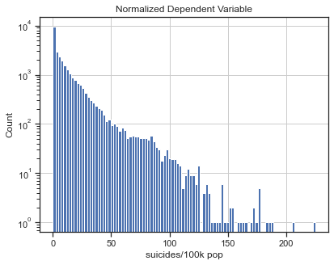

```python
# Plot the dependent variable
dfOrg['suicides/100k pop'].hist(bins=100, log=True)
plt.title('Normalized Dependent Variable')
plt.xlabel('suicides/100k pop')
plt.ylabel('Count')
plt.show()
```

```python
# Check types of features
print(dfOrg.dtypes)
```

```
country                object
year                    int64
sex                    object
age                    object
suicides_no             int64
population              int64
suicides/100k pop     float64
country-year           object
HDI for year          float64
 gdp_for_year ($)       int64
gdp_per_capita ($)      int64
generation             object
dtype: object
```

```python
# Aggregate over sex, year and generation
df2 = dfOrg.copy()
df2 = df2.groupby(['sex', 'year', 'generation']).mean(numeric_only=True)
df2 = df2.reset_index()
print(len(df2))

# Sanity
df2.head()
```

```
292
```

|  | sex | year | generation | suicides_no | population | suicides/100k pop | HDI for year | gdp_for_year ($) | gdp_per_capita ($) |
| --- | --- | --- | --- | --- | --- | --- | --- | --- | --- |
| 0 | female | 1985 | Boomers | 101.958333 | 1.802462e+06 | 4.740208 | 0.699162 | 1.926471e+11 | 6091.229167 |
| 1 | female | 1985 | G.I. Generation | 136.125000 | 1.121183e+06 | 9.500208 | 0.699162 | 1.926471e+11 | 6091.229167 |
| 2 | female | 1985 | Generation X | 52.510417 | 2.030158e+06 | 2.544479 | 0.699162 | 1.926471e+11 | 6091.229167 |
| 3 | female | 1985 | Silent | 197.416667 | 2.582628e+06 | 5.831875 | 0.699162 | 1.926471e+11 | 6091.229167 |
| 4 | female | 1986 | Boomers | 105.375000 | 1.836482e+06 | 5.090208 | NaN | 2.302251e+11 | 7126.104167 |

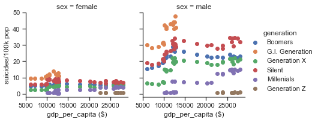

```python
# Plot for data exploration
g = sns.FacetGrid(df2, col='sex', hue='generation')
g.map(plt.scatter, 'gdp_per_capita ($)', 'suicides/100k pop')
_ = g.add_legend()
```

```python
# Check the year range for the plot x-axis order
print(df2['year'].min(), df2['year'].max())
```

```
1985 2016
```

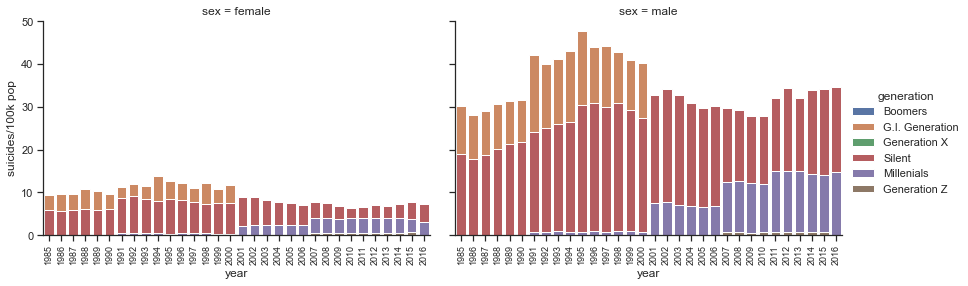

```python
# Plot for data exploration
g = sns.FacetGrid(df2, col='sex', hue='generation', height=4, aspect=1.5)
g.map(sns.barplot, 'year', 'suicides/100k pop', order=np.arange(1985,2017))
g.set_xticklabels(rotation=90, fontsize=9)
_ = g.add_legend()
```

```python
# Aggregate over age and year
df3 = dfOrg.copy()
df3 = df3.groupby(['age', 'year']).mean(numeric_only=True)
df3 = df3.reset_index()
print(len(df3))

# Sanity
df3.head()
```

```
191
```

|  | age | year | suicides_no | population | suicides/100k pop | HDI for year | gdp_for_year ($) | gdp_per_capita ($) |
| --- | --- | --- | --- | --- | --- | --- | --- | --- |
| 0 | 15-24 years | 1985 | 186.145833 | 2.051817e+06 | 8.429688 | 0.699162 | 1.926471e+11 | 6091.229167 |
| 1 | 15-24 years | 1986 | 188.156250 | 2.075402e+06 | 8.152083 | NaN | 2.302251e+11 | 7126.104167 |
| 2 | 15-24 years | 1987 | 152.148148 | 1.931372e+06 | 7.487870 | NaN | 2.403856e+11 | 8712.592593 |
| 3 | 15-24 years | 1988 | 156.500000 | 2.000362e+06 | 8.750918 | NaN | 2.985675e+11 | 9983.857143 |
| 4 | 15-24 years | 1989 | 179.192308 | 2.114683e+06 | 9.160481 | NaN | 3.070805e+11 | 9725.038462 |

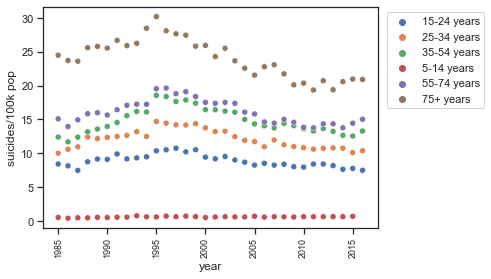

```python
# More plots
plt.figure(figsize=(6, 4), dpi=72)
sns.scatterplot(x='year', y='suicides/100k pop', hue='age', data=df3)
plt.xticks(rotation=90, fontsize=9)
_ = plt.legend(bbox_to_anchor=(1.01, 1.0))
```

```python
# Aggregate over generation and country
df4 = dfOrg.copy()
df4 = df4.groupby(['generation', 'country']).mean(numeric_only=True)
df4 = df4.reset_index()
print(len(df4))

# Sanity
df4.head()
```

```
590
```

|  | generation | country | year | suicides_no | population | suicides/100k pop | HDI for year | gdp_for_year ($) | gdp_per_capita ($) |
| --- | --- | --- | --- | --- | --- | --- | --- | --- | --- |
| 0 | Boomers | Albania | 1998.000000 | 12.020833 | 3.444468e+05 | 3.377708 | 0.656667 | 4.443866e+09 | 1580.208333 |
| 1 | Boomers | Antigua and Barbuda | 1998.580645 | 0.112903 | 8.430129e+03 | 1.238548 | 0.781667 | 7.677842e+08 | 10183.193548 |
| 2 | Boomers | Argentina | 1998.823529 | 278.750000 | 3.452533e+06 | 7.960147 | 0.776111 | 2.644416e+11 | 7769.970588 |
| 3 | Boomers | Armenia | 2001.142857 | 11.803571 | 3.776771e+05 | 3.339286 | 0.685714 | 4.718644e+09 | 1624.142857 |
| 4 | Boomers | Aruba | 2003.846154 | 1.500000 | 1.546704e+04 | 10.336154 | NaN | 2.175340e+09 | 24086.846154 |

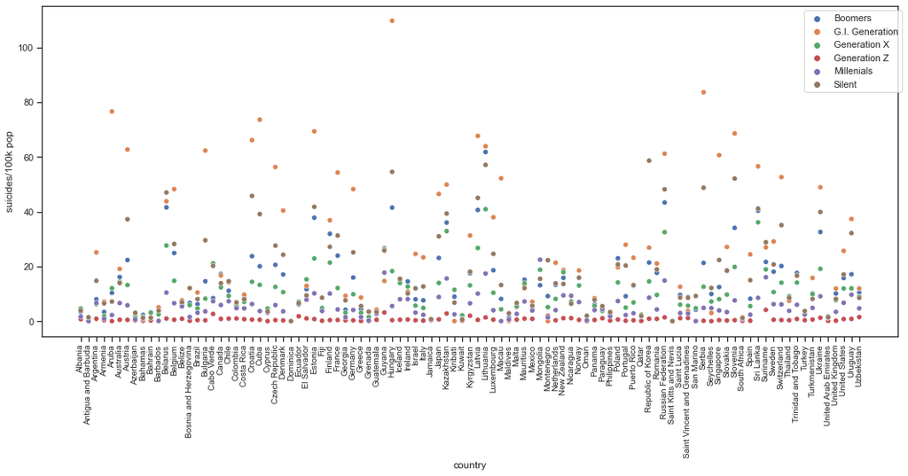

```python
# More plots
plt.figure(figsize=(18, 7), dpi=72)
sns.scatterplot(x='country', y='suicides/100k pop', hue='generation', data=df4)
plt.xticks(rotation=90, fontsize=10)
_ = plt.legend(bbox_to_anchor=(1.01, 1.0))
```

## References

1. Raschka, Sebastian, et al. Machine Learning with PyTorch and Scikit-Learn: Develop machine learning and deep learning models with Python. Packt Publishing Ltd, 2022.
2. Bojer, Casper Solheim, and Jens Peder Meldgaard. "Kaggle forecasting competitions: An overlooked learning opportunity." International Journal of Forecasting 37.2 (2021): 587-603.
3. Witten, Ian H., et al. "Practical machine learning tools and techniques." Data Mining. Fourth Edition, Elsevier Publishers (2017).

## Exercises

**Exercise 1.** Find a popular image dataset in Kaggle and report its name.

**Exercise 2.** Using the feature exploration above pick two features for classification to predict dependent variable. Discuss your reasons.

**Exercise 3.** In Weka try three more classifiers and report their performance. Check the dependent variable constraints in API and pick one classifier that uses numerical feature as its dependent variable.

**Exercise 4.** Using the plots above, answer: What should be the independent variable? Find out which age group has a stronger relation to a high suicide rate. Which gender has it?

```python
%%html
<style>
    table {margin-left: 0 !important;}
    p {font-family: verdana;}
    li {font-family: verdana;}
    div {font-size: 10pt;}
</style>
<!-- Display markdown tables left oriented in this notebook. -->
```